# Exploratory data anylysis

```python
import pandas as pd
import numpy as np



import geopandas as gpd
from geopandas.tools import geocode

import re

from datetime import datetime

from shapely.geometry import LineString, MultiPolygon, Polygon
from shapely.ops import split
from shapely.affinity import translate


from matplotlib import pyplot as plt

import warnings
warnings.filterwarnings('ignore')
```

```python
from shapely.geometry import Point
```

```python
import seaborn as sns
```

```python
from geopandas import GeoDataFrame
```

```python
!pip install seaborn
```

```
  Using cached seaborn-0.12.2-py3-none-any.whl (293 kB)
```

# Import data

df:

- num
- brand
- model
- year
- description
- location
- price

salary:

- region
- median_salary
- num
- Region number
- NAME Region

```python
df = pd.read_csv("data_cars/auto_mers.csv")
```

```python
salary = pd.read_csv("data_cars/regions_with_salary.csv")
```

```python
# https://www.kaggle.com/datasets/kapral42/russia-geo-data
rus_bnd_gdf = gpd.read_file('data_cars/geo.json')

median_salary = salary.loc[0, 'median_salary'] #loc[1 argument - name row, 2 argument - name column], return means for arguments in loc
```

```python
print(median_salary)
```

```
62199.7
```

```python
df.head()
```

|  | num | brand | model | year | description | location | price |
| --- | --- | --- | --- | --- | --- | --- | --- |
| 0 | 1 | Mercedes-Benz | E-Class | 2006 | 3.2 л (204 л.с.), дизель, АКПП, задний, 350 ты... | Майкоп | 830000 |
| 1 | 1 | Mercedes-Benz | Mercedes | 1992 | 2.3 л (136 л.с.), бензин, механика, задний, 22... | Майкоп | 300000 |
| 2 | 1 | Mercedes-Benz | E-Class | 1999 | 2.8 л (193 л.с.), бензин, автомат, задний, 360... | Дондуковская | 280000 |
| 3 | 1 | Mercedes-Benz | E-Class | 1991 | 3.0 л (220 л.с.), бензин, АКПП, задний, 352 ты... | Тахтамукай | 200000 |
| 4 | 1 | Mercedes-Benz | C-Class | 2011 | 1.8 л (156 л.с.), бензин, АКПП, задний, 134 ты... | Майкоп | 900000 |

```python
df.tail()
```

|  | num | brand | model | year | description | location | price |
| --- | --- | --- | --- | --- | --- | --- | --- |
| 27135 | 89 | Mercedes-Benz | M-Class | 2007 | 5.0 л (306 л.с.), бензин, АКПП, 4WD, 299 тыс. км | Новый Уренгой | 1000000 |
| 27136 | 89 | Mercedes-Benz | E-Class | 2005 | 3.5 л (272 л.с.), бензин, АКПП, задний, 350 ты... | Новый Уренгой | 550000 |
| 27137 | 89 | Mercedes-Benz | M-Class | 1998 | 3.2 л (218 л.с.), бензин, АКПП, 4WD, 398 тыс. км | Ноябрьск | 550000 |
| 27138 | 89 | Mercedes-Benz | E-Class | 1999 | 2.4 л (170 л.с.), бензин, механика, задний, 30... | Ноябрьск | 300000 |
| 27139 | 89 | Mercedes-Benz | CLS-Class | 2007 | 5.5 л (388 л.с.), бензин, АКПП, задний, 164 ты... | Губкинский | 1600000 |

```python
df[:4] #first 4 row
```

|  | num | brand | model | year | description | location | price |
| --- | --- | --- | --- | --- | --- | --- | --- |
| 0 | 1 | Mercedes-Benz | E-Class | 2006 | 3.2 л (204 л.с.), дизель, АКПП, задний, 350 ты... | Майкоп | 830000 |
| 1 | 1 | Mercedes-Benz | Mercedes | 1992 | 2.3 л (136 л.с.), бензин, механика, задний, 22... | Майкоп | 300000 |
| 2 | 1 | Mercedes-Benz | E-Class | 1999 | 2.8 л (193 л.с.), бензин, автомат, задний, 360... | Дондуковская | 280000 |
| 3 | 1 | Mercedes-Benz | E-Class | 1991 | 3.0 л (220 л.с.), бензин, АКПП, задний, 352 ты... | Тахтамукай | 200000 |

```python
salary[:4]
```

|  | region | median_salary | num | Region_en | NAME_1 |
| --- | --- | --- | --- | --- | --- |
| 0 | Российская Федерация | 62199.7 | 0 | NaN | NaN |
| 1 | Белгородская область | 46406.6 | 31 | Belgorod region | Belgorod |
| 2 | Брянская область | 39434.4 | 32 | Bryansk region | Bryansk |
| 3 | Владимирская область | 44136.4 | 33 | Vladimir region | Vladimir |

```python
rus_bnd_gdf[:4]
```

|  | ID_0 | ISO | NAME_0 | ID_1 | NAME_1 | NL_NAME_1 | VARNAME_1 | TYPE_1 | ENGTYPE_1 | geometry |
| --- | --- | --- | --- | --- | --- | --- | --- | --- | --- | --- |
| 0 | 186 | RUS | Russia | 28 | Karachay-Cherkess | ?????????-????????? ?????????? | Karaçay-Çerkes\|Karachay-Cherkessiya\|Karachayev... | Respublika | Republic | POLYGON ((42.13194 44.34488, 42.19061 44.32248... |
| 1 | 186 | RUS | Russia | 29 | Karelia | ?????????? ??????? | Karelian A.S.S.R.\|Karelo-Finnish A.S.S.R.\|Kare... | Respublika | Republic | MULTIPOLYGON (((36.77098 64.02402, 36.75969 64... |
| 2 | 186 | RUS | Russia | 30 | Kemerovo | ??????????? ??????? | Kemerovskaya Oblast | Oblast | Region | POLYGON ((88.63731 56.77809, 88.64615 56.73922... |
| 3 | 186 | RUS | Russia | 31 | Khabarovsk | ??????????? ???? | Khabarovskiy Kray | Kray | Territory | MULTIPOLYGON (((136.64362 45.04694, 136.64417 ... |

```python
df = df[df.model != 'Mercedes']  #delite model 'Mercedes', because it is not model, it is brand
```

```python
df.shape #count row and column
```

```
(26814, 7)
```

```python
salary.shape
```

```
(154, 5)
```

Merge tables (part of region hasn't in salary table 'salary') and add flag than, biggest average salary in this rtegion, than median salary in Russia (флаг больше ли средняя ЗП в данном регионе, чем средняя по России (брались медианы))

```python
df = pd.merge(df, salary, on = 'num', how = 'inner') #marge - сливать - merge table
df['flg_more_average_salary'] = (df['median_salary'] > median_salary).astype(int) #if median salary>RFmedian salary ->1, if not - 0
```

```python
df.head()
```

|  | num | brand | model | year | description | location | price | region | median_salary | Region_en | NAME_1 | flg_more_average_salary |
| --- | --- | --- | --- | --- | --- | --- | --- | --- | --- | --- | --- | --- |
| 0 | 1 | Mercedes-Benz | E-Class | 2006 | 3.2 л (204 л.с.), дизель, АКПП, задний, 350 ты... | Майкоп | 830000 | Республика Адыгея | 38435.1 | Republic of Adygea | Adygey | 0 |
| 1 | 1 | Mercedes-Benz | E-Class | 1999 | 2.8 л (193 л.с.), бензин, автомат, задний, 360... | Дондуковская | 280000 | Республика Адыгея | 38435.1 | Republic of Adygea | Adygey | 0 |
| 2 | 1 | Mercedes-Benz | E-Class | 1991 | 3.0 л (220 л.с.), бензин, АКПП, задний, 352 ты... | Тахтамукай | 200000 | Республика Адыгея | 38435.1 | Republic of Adygea | Adygey | 0 |
| 3 | 1 | Mercedes-Benz | C-Class | 2011 | 1.8 л (156 л.с.), бензин, АКПП, задний, 134 ты... | Майкоп | 900000 | Республика Адыгея | 38435.1 | Republic of Adygea | Adygey | 0 |
| 4 | 1 | Mercedes-Benz | A-Class | 2000 | 1.6 л (102 л.с.), бензин, механика, передний, ... | Хатукай | 250000 | Республика Адыгея | 38435.1 | Republic of Adygea | Adygey | 0 |

```python
df.tail()
```

|  | num | brand | model | year | description | location | price | region | median_salary | Region_en | NAME_1 | flg_more_average_salary |
| --- | --- | --- | --- | --- | --- | --- | --- | --- | --- | --- | --- | --- |
| 26809 | 89 | Mercedes-Benz | M-Class | 2007 | 5.0 л (306 л.с.), бензин, АКПП, 4WD, 299 тыс. км | Новый Уренгой | 1000000 | Ямало-Ненецкий автономный округ | 130037.6 | Yamalo-Nenets Autonomous Okrug | Yamal-Nenets | 1 |
| 26810 | 89 | Mercedes-Benz | E-Class | 2005 | 3.5 л (272 л.с.), бензин, АКПП, задний, 350 ты... | Новый Уренгой | 550000 | Ямало-Ненецкий автономный округ | 130037.6 | Yamalo-Nenets Autonomous Okrug | Yamal-Nenets | 1 |
| 26811 | 89 | Mercedes-Benz | M-Class | 1998 | 3.2 л (218 л.с.), бензин, АКПП, 4WD, 398 тыс. км | Ноябрьск | 550000 | Ямало-Ненецкий автономный округ | 130037.6 | Yamalo-Nenets Autonomous Okrug | Yamal-Nenets | 1 |
| 26812 | 89 | Mercedes-Benz | E-Class | 1999 | 2.4 л (170 л.с.), бензин, механика, задний, 30... | Ноябрьск | 300000 | Ямало-Ненецкий автономный округ | 130037.6 | Yamalo-Nenets Autonomous Okrug | Yamal-Nenets | 1 |
| 26813 | 89 | Mercedes-Benz | CLS-Class | 2007 | 5.5 л (388 л.с.), бензин, АКПП, задний, 164 ты... | Губкинский | 1600000 | Ямало-Ненецкий автономный округ | 130037.6 | Yamalo-Nenets Autonomous Okrug | Yamal-Nenets | 1 |

```python
df.info()
```

```
<class 'pandas.core.frame.DataFrame'>
Int64Index: 26814 entries, 0 to 26813
Data columns (total 12 columns):
 #   Column                   Non-Null Count  Dtype
---  ------                   --------------  -----
 0   num                      26814 non-null  int64
 1   brand                    26814 non-null  object
 2   model                    26814 non-null  object
 3   year                     26814 non-null  int64
 4   description              26814 non-null  object
 5   location                 26814 non-null  object
 6   price                    26814 non-null  int64
 7   region                   26814 non-null  object
 8   median_salary            26814 non-null  float64
 9   Region_en                26814 non-null  object
 10  NAME_1                   26814 non-null  object
 11  flg_more_average_salary  26814 non-null  int32
dtypes: float64(1), int32(1), int64(3), object(7)
memory usage: 2.6+ MB
```

```python
df.describe() #basic function; std - СКО (squart(sum(xi - xavg)**2/n), mean - avarage means
```

|  | num | year | price | median_salary | flg_more_average_salary |
| --- | --- | --- | --- | --- | --- |
| count | 26814.000000 | 26814.000000 | 2.681400e+04 | 26814.000000 | 26814.000000 |
| mean | 48.268703 | 2010.324457 | 2.826853e+06 | 59158.197285 | 0.272097 |
| std | 25.398777 | 8.173165 | 4.147156e+06 | 22507.835182 | 0.445048 |
| min | 1.000000 | 1940.000000 | 2.500000e+04 | 31348.600000 | 0.000000 |
| 25% | 25.000000 | 2005.000000 | 7.950000e+05 | 44670.500000 | 0.000000 |
| 50% | 50.000000 | 2012.000000 | 1.568950e+06 | 50292.800000 | 0.000000 |
| 75% | 72.000000 | 2017.000000 | 3.190000e+06 | 62201.700000 | 1.000000 |
| max | 102.000000 | 2022.000000 | 9.500000e+07 | 136166.900000 | 1.000000 |

```python
df.describe(include='object') #basic describe with object (means not degree - descriotion)
```

|  | brand | model | description | location | region | Region_en | NAME_1 |
| --- | --- | --- | --- | --- | --- | --- | --- |
| count | 26814 | 26814 | 26814 | 26814 | 26814 | 26814 | 26814 |
| unique | 1 | 41 | 10906 | 1236 | 82 | 82 | 82 |
| top | Mercedes-Benz | E-Class | 2.9 л (330 л.с.), дизель, АКПП, 4WD | Москва | Москва | Moscow | Moscow City |
| freq | 26814 | 6544 | 98 | 2130 | 2130 | 2130 | 2130 |

# Exploratory data anylysis (исследовательский анализ данных)

## Feature ingineering (проектирование функций)

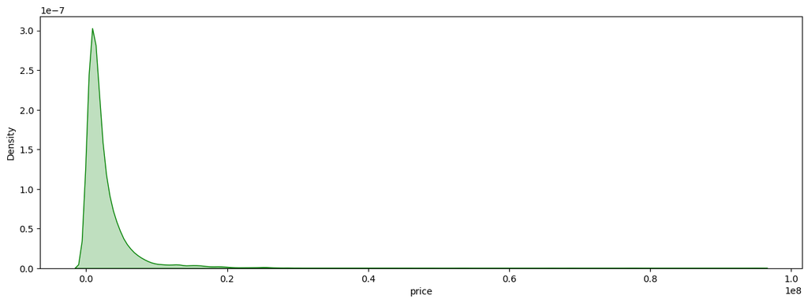

```python
plt.figure(figsize=(15, 5)) #Create a new figure, or activate an existing figure.
sns.kdeplot(df['price'], palette='red', fill=True, color ='green') #Plot univariate or bivariate distributions using kernel density estimation (оценка плотности).
#fill - заливка
plt.show()  #show grathic
```

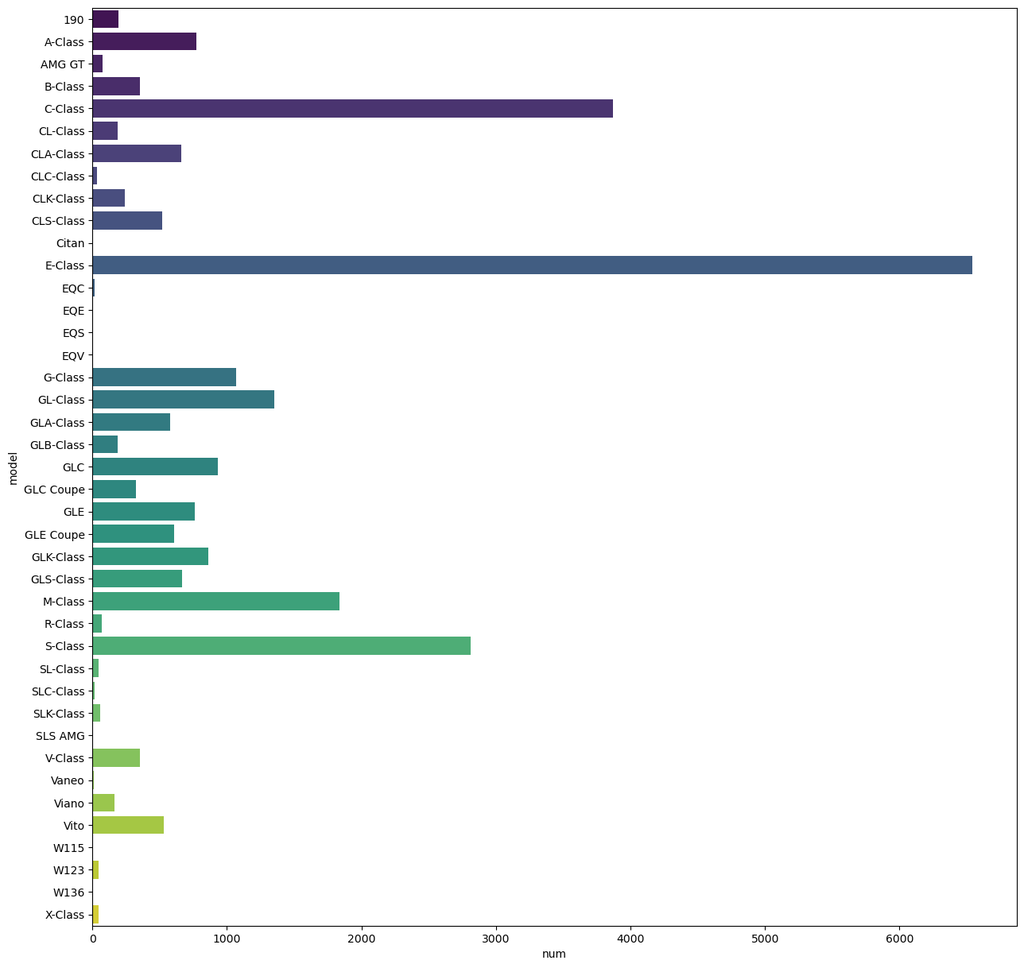

```python
plt.figure(figsize=(15, 15)) #Create a new figure, or activate an existing figure.

sns.barplot(data=df.groupby('model')[['num']].count().reset_index(), #groupby - group by parametr, reset_index()-set index 0 untill long data
        x='num',
        y='model',
        palette='viridis')
plt.show()
```

```python
groups_count = df.groupby('model')['num'].count()
drop_models = groups_count[groups_count <= 15].index
df = df[~df.model.isin(drop_models)] #isin() is used to filter data frames. isin()  helps in selecting rows with having a value
```

```python
df.head()
```

|  | num | brand | model | year | description | location | price | region | median_salary | Region_en | NAME_1 | flg_more_average_salary |
| --- | --- | --- | --- | --- | --- | --- | --- | --- | --- | --- | --- | --- |
| 0 | 1 | Mercedes-Benz | E-Class | 2006 | 3.2 л (204 л.с.), дизель, АКПП, задний, 350 ты... | Майкоп | 830000 | Республика Адыгея | 38435.1 | Republic of Adygea | Adygey | 0 |
| 1 | 1 | Mercedes-Benz | E-Class | 1999 | 2.8 л (193 л.с.), бензин, автомат, задний, 360... | Дондуковская | 280000 | Республика Адыгея | 38435.1 | Republic of Adygea | Adygey | 0 |
| 2 | 1 | Mercedes-Benz | E-Class | 1991 | 3.0 л (220 л.с.), бензин, АКПП, задний, 352 ты... | Тахтамукай | 200000 | Республика Адыгея | 38435.1 | Republic of Adygea | Adygey | 0 |
| 3 | 1 | Mercedes-Benz | C-Class | 2011 | 1.8 л (156 л.с.), бензин, АКПП, задний, 134 ты... | Майкоп | 900000 | Республика Адыгея | 38435.1 | Republic of Adygea | Adygey | 0 |
| 4 | 1 | Mercedes-Benz | A-Class | 2000 | 1.6 л (102 л.с.), бензин, механика, передний, ... | Хатукай | 250000 | Республика Адыгея | 38435.1 | Republic of Adygea | Adygey | 0 |

```python
df.shape
```

```
(26769, 12)
```

```python
df[df.brand == 'Mercedes-Benz'].groupby('region')[['price']].median()
```

| region | price |
| --- | --- |
| Алтайский край | 1199000.0 |
| Амурская область | 1580000.0 |
| Архангельская область | 1100000.0 |
| Астраханская область | 1247500.0 |
| Белгородская область | 1192000.0 |
| ... | ... |
| Чеченская Республика | 1170000.0 |
| Чувашская Республика | 1695000.0 |
| Чукотский автономный округ | 1050000.0 |
| Ямало-Ненецкий автономный округ | 1300000.0 |
| Ярославская область | 1750000.0 |

82 rows × 1 columns

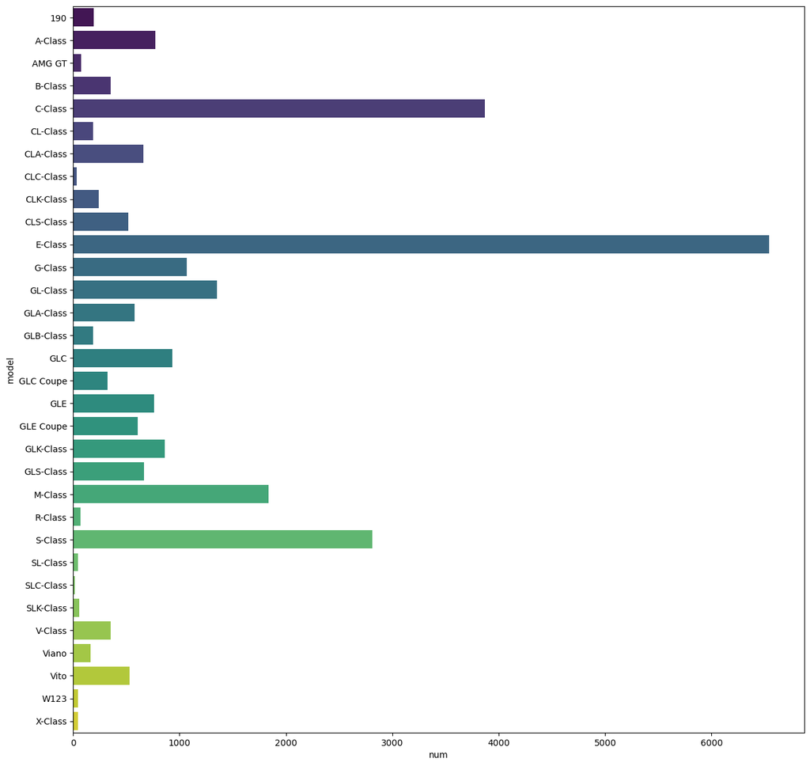

```python
plt.figure(figsize=(15, 15)) #Create a new figure, or activate an existing figure.

sns.barplot(data=df.groupby('model')[['num']].count().reset_index(),
        x='num',
        y='model',
        palette='viridis')
plt.show()
```

```python
df['age'] = [datetime.now().year] - df['year'] #add new parametr
```

Clean any means of parametrs

```python
df[df.region == 'Республика Адыгея'].groupby('location')[['price']].median()
```

| location | price |
| --- | --- |
| Апшеронск (≈ 50 км) | 950000.0 |
| Белореченск (≈ 30 км) | 950000.0 |
| Дондуковская | 280000.0 |
| Лабинск (≈ 60 км) | 1200000.0 |
| Майкоп | 1015000.0 |
| Тахтамукай | 300000.0 |
| Хадыженск (≈ 70 км) | 600000.0 |
| Ханская | 1700000.0 |
| Хатукай | 250000.0 |
| Яблоновский | 4450000.0 |

```python
df[df.region == 'Ямало-Ненецкий автономный округ'].groupby('location')[['price']].median()
```

| location | price |
| --- | --- |
| Вуктыл (≈ 1 250 км) | 150000.0 |
| Губкинский | 1450000.0 |
| Емва (≈ 1 500 км) | 430000.0 |
| Лабытнанги | 550000.0 |
| Муравленко | 1050000.0 |
| Надым | 1390000.0 |
| Новый Уренгой | 1750000.0 |
| Ноябрьск | 1375000.0 |
| Пангоды | 500000.0 |
| Салехард | 1825000.0 |
| Советский (≈ 1 800 км) | 1035000.0 |
| Сыктывкар (≈ 1 600 км) | 1300000.0 |
| Тарко-Сале | 1350000.0 |
| Уренгой | 1300000.0 |
| Усть-Цильма (≈ 1 350 км) | 660000.0 |
| Ухта (≈ 1 300 км) | 800000.0 |
| Югорск (≈ 1 800 км) | 1600000.0 |

```python
df[df.region == 'Республика Адыгея'].groupby('location')[['price']].count()
```

| location | price |
| --- | --- |
| Апшеронск (≈ 50 км) | 2 |
| Белореченск (≈ 30 км) | 27 |
| Дондуковская | 3 |
| Лабинск (≈ 60 км) | 12 |
| Майкоп | 22 |
| Тахтамукай | 4 |
| Хадыженск (≈ 70 км) | 5 |
| Ханская | 2 |
| Хатукай | 2 |
| Яблоновский | 8 |

```python
df.drop('location', axis=1, inplace=True) #delite parametr location, because it is not important
```

Change geo information for imagine on cart, add average salary

```python
# https://stackoverflow.com/questions/66833670/geopandas-map-centering-with-countries
```

```python
def shift_geom(shift, row):#shift -сдвиг
    shift -= 180
    moved_map = []
    splitted_map = []
    border = LineString([(shift, 90), (shift, -90)])

    splitted_map = split(row, border) #border - граница
    items = list(splitted_map)

    for item in items:
        minx, miny, maxx, maxy = item.bounds
        if minx >= shift:
            moved_map.append(translate(item, xoff=-180 - shift))
        else:
            moved_map.append(translate(item, xoff=180 - shift))

    gdf = gpd.GeoDataFrame({"geometry": moved_map})
    return gdf.geometry.unary_union
```

```python
russia_salary_geo = gpd.GeoDataFrame(
    pd.merge(salary,
             rus_bnd_gdf[['NAME_1', 'geometry']],
             on ='NAME_1',
             how='left'))
```

```python
russia_salary_geo[russia_salary_geo.median_salary > 100000] #df[df.liters < 1]
```

|  | region | median_salary | num | Region_en | NAME_1 | geometry |
| --- | --- | --- | --- | --- | --- | --- |
| 24 | Москва | 114700.7 | 77 | Moscow | Moscow City | MULTIPOLYGON (((37.24789 55.58891, 37.24775 55... |
| 25 | Москва | 114700.7 | 97 | Moscow | Moscow City | MULTIPOLYGON (((37.24789 55.58891, 37.24775 55... |
| 26 | Москва | 114700.7 | 99 | Moscow | Moscow City | MULTIPOLYGON (((37.24789 55.58891, 37.24775 55... |
| 27 | Москва | 114700.7 | 177 | Moscow | Moscow City | MULTIPOLYGON (((37.24789 55.58891, 37.24775 55... |
| 28 | Москва | 114700.7 | 197 | Moscow | Moscow City | MULTIPOLYGON (((37.24789 55.58891, 37.24775 55... |
| 29 | Москва | 114700.7 | 199 | Moscow | Moscow City | MULTIPOLYGON (((37.24789 55.58891, 37.24775 55... |
| 30 | Москва | 114700.7 | 777 | Moscow | Moscow City | MULTIPOLYGON (((37.24789 55.58891, 37.24775 55... |
| 31 | Москва | 114700.7 | 797 | Moscow | Moscow City | MULTIPOLYGON (((37.24789 55.58891, 37.24775 55... |
| 32 | Москва | 114700.7 | 799 | Moscow | Moscow City | MULTIPOLYGON (((37.24789 55.58891, 37.24775 55... |
| 33 | Москва | 114700.7 | 977 | Moscow | Moscow City | MULTIPOLYGON (((37.24789 55.58891, 37.24775 55... |
| 38 | Ненецкий автономный округ | 100573.2 | 83 | Nenets Autonomous Okrug | Nenets | MULTIPOLYGON (((46.55648 66.82972, 46.55838 66... |
| 116 | Ямало-Ненецкий автономный округ | 130037.6 | 89 | Yamalo-Nenets Autonomous Okrug | Yamal-Nenets | MULTIPOLYGON (((72.23459 66.26912, 72.23849 66... |
| 150 | Магаданская область | 115585.7 | 49 | Magadan Region | Maga Buryatdan | MULTIPOLYGON (((152.73358 58.90553, 152.73305 ... |
| 151 | Сахалинская область | 102796.8 | 65 | Sakhalin region | Sakhalin | MULTIPOLYGON (((146.01648 43.37832, 146.01736 ... |
| 153 | Чукотский автономный округ | 136166.9 | 87 | Chukotka Autonomous Okrug | Chukot | MULTIPOLYGON (((-172.67111 64.64882, -172.6496... |

```python
russia_salary_geo.drop(153)
```

|  | region | median_salary | num | Region_en | NAME_1 | geometry |
| --- | --- | --- | --- | --- | --- | --- |
| 0 | Российская Федерация | 62199.7 | 0 | NaN | NaN | None |
| 1 | Белгородская область | 46406.6 | 31 | Belgorod region | Belgorod | POLYGON ((38.10826 51.38651, 38.14936 51.35922... |
| 2 | Брянская область | 39434.4 | 32 | Bryansk region | Bryansk | POLYGON ((33.83619 53.97201, 33.95209 53.85182... |
| 3 | Владимирская область | 44136.4 | 33 | Vladimir region | Vladimir | POLYGON ((39.88538 56.76500, 39.89406 56.69862... |
| 4 | Воронежская область | 45142.4 | 36 | Voronezh region | Voronezh | POLYGON ((38.77813 52.08555, 38.81647 52.07509... |
| ... | ... | ... | ... | ... | ... | ... |
| 148 | Хабаровский край | 62201.7 | 27 | Khabarovsk region | Khabarovsk | MULTIPOLYGON (((136.64362 45.04694, 136.64417 ... |
| 149 | Амурская область | 63730.8 | 28 | Amurskaya Oblast | Amur | POLYGON ((120.67429 57.05607, 120.73457 57.040... |
| 150 | Магаданская область | 115585.7 | 49 | Magadan Region | Maga Buryatdan | MULTIPOLYGON (((152.73358 58.90553, 152.73305 ... |
| 151 | Сахалинская область | 102796.8 | 65 | Sakhalin region | Sakhalin | MULTIPOLYGON (((146.01648 43.37832, 146.01736 ... |
| 152 | Еврейская автономная область | 54263.7 | 79 | Jewish Autonomous Region | Yevrey | POLYGON ((132.38721 49.31974, 132.46678 49.279... |

153 rows × 6 columns

```python
russia_salary_geo = russia_salary_geo[russia_salary_geo.NAME_1 != 'Chukot']
```

```python
russia_salary_geo[russia_salary_geo.median_salary > 100000] #df[df.liters < 1]
```

|  | region | median_salary | num | Region_en | NAME_1 | geometry |
| --- | --- | --- | --- | --- | --- | --- |
| 24 | Москва | 114700.7 | 77 | Moscow | Moscow City | MULTIPOLYGON (((37.24789 55.58891, 37.24775 55... |
| 25 | Москва | 114700.7 | 97 | Moscow | Moscow City | MULTIPOLYGON (((37.24789 55.58891, 37.24775 55... |
| 26 | Москва | 114700.7 | 99 | Moscow | Moscow City | MULTIPOLYGON (((37.24789 55.58891, 37.24775 55... |
| 27 | Москва | 114700.7 | 177 | Moscow | Moscow City | MULTIPOLYGON (((37.24789 55.58891, 37.24775 55... |
| 28 | Москва | 114700.7 | 197 | Moscow | Moscow City | MULTIPOLYGON (((37.24789 55.58891, 37.24775 55... |
| 29 | Москва | 114700.7 | 199 | Moscow | Moscow City | MULTIPOLYGON (((37.24789 55.58891, 37.24775 55... |
| 30 | Москва | 114700.7 | 777 | Moscow | Moscow City | MULTIPOLYGON (((37.24789 55.58891, 37.24775 55... |
| 31 | Москва | 114700.7 | 797 | Moscow | Moscow City | MULTIPOLYGON (((37.24789 55.58891, 37.24775 55... |
| 32 | Москва | 114700.7 | 799 | Moscow | Moscow City | MULTIPOLYGON (((37.24789 55.58891, 37.24775 55... |
| 33 | Москва | 114700.7 | 977 | Moscow | Moscow City | MULTIPOLYGON (((37.24789 55.58891, 37.24775 55... |
| 38 | Ненецкий автономный округ | 100573.2 | 83 | Nenets Autonomous Okrug | Nenets | MULTIPOLYGON (((46.55648 66.82972, 46.55838 66... |
| 116 | Ямало-Ненецкий автономный округ | 130037.6 | 89 | Yamalo-Nenets Autonomous Okrug | Yamal-Nenets | MULTIPOLYGON (((72.23459 66.26912, 72.23849 66... |
| 150 | Магаданская область | 115585.7 | 49 | Magadan Region | Maga Buryatdan | MULTIPOLYGON (((152.73358 58.90553, 152.73305 ... |
| 151 | Сахалинская область | 102796.8 | 65 | Sakhalin region | Sakhalin | MULTIPOLYGON (((146.01648 43.37832, 146.01736 ... |

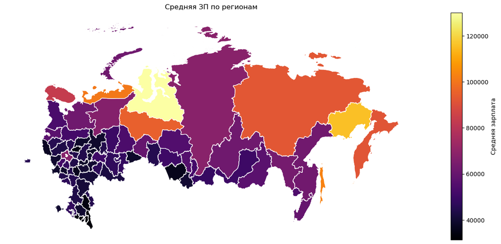

```python
colors = ['viridis', 'plasma', 'inferno', 'magma', 'cividis']

mo_gdf_wm = russia_salary_geo.to_crs({'init':
                                      'epsg:4326'})  # преобразование проекции
mo_gdf_wm.plot(column='median_salary',
               linewidth=1,
               cmap=colors[2],
               legend=True,
               figsize=[20, 7],
               legend_kwds={
                   'label': "Средняя зарплата",
                   'orientation': "vertical"
               },
               edgecolor="white",
               aspect='auto')
plt.title('Средняя ЗП по регионам')
plt.axis('off')
plt.show()
```

Распарсим description по полям

```python
def parsing_desc(data: str) -> list:
    try:
        # Если нет пробега
        if 'тыс. км' not in data:
            data += ', 0 тыс. км'

        lst = data.split(', ')
        ltr, type_engine, transm, machine_drive, mileage = lst[0], lst[1], lst[
            2], lst[3], lst[4]

        liters = float(ltr.split()[0])
        horsepower = int(re.sub(r"[^\d]", '', ltr.split()[2])) #function replaces one or many matches with a string in the given tex
        mileage = int(re.sub(r"[^\d]", '', mileage)) # [^\d] == [^0-9] replace all elements except degree 0-9
        mileage = 0 if mileage == 1 else mileage

        return [
            liters, horsepower, type_engine, transm, machine_drive, mileage
        ]
    except:
        return None
```

```python
df['full_desc'] = df['description'].transform(lambda x: parsing_desc(x)) #add new column
```

```python
df.head()
```

|  | num | brand | model | year | description | price | region | median_salary | Region_en | NAME_1 | flg_more_average_salary | age | full_desc |
| --- | --- | --- | --- | --- | --- | --- | --- | --- | --- | --- | --- | --- | --- |
| 0 | 1 | Mercedes-Benz | E-Class | 2006 | 3.2 л (204 л.с.), дизель, АКПП, задний, 350 ты... | 830000 | Республика Адыгея | 38435.1 | Republic of Adygea | Adygey | 0 | 17 | [3.2, 204, дизель, АКПП, задний, 350] |
| 1 | 1 | Mercedes-Benz | E-Class | 1999 | 2.8 л (193 л.с.), бензин, автомат, задний, 360... | 280000 | Республика Адыгея | 38435.1 | Republic of Adygea | Adygey | 0 | 24 | [2.8, 193, бензин, автомат, задний, 360] |
| 2 | 1 | Mercedes-Benz | E-Class | 1991 | 3.0 л (220 л.с.), бензин, АКПП, задний, 352 ты... | 200000 | Республика Адыгея | 38435.1 | Republic of Adygea | Adygey | 0 | 32 | [3.0, 220, бензин, АКПП, задний, 352] |
| 3 | 1 | Mercedes-Benz | C-Class | 2011 | 1.8 л (156 л.с.), бензин, АКПП, задний, 134 ты... | 900000 | Республика Адыгея | 38435.1 | Republic of Adygea | Adygey | 0 | 12 | [1.8, 156, бензин, АКПП, задний, 134] |
| 4 | 1 | Mercedes-Benz | A-Class | 2000 | 1.6 л (102 л.с.), бензин, механика, передний, ... | 250000 | Республика Адыгея | 38435.1 | Republic of Adygea | Adygey | 0 | 23 | [1.6, 102, бензин, механика, передний, 228] |

```python
df_parse = df["full_desc"].apply(pd.Series) #apply == map, pd.Series - create data from list
df_parse.columns = [
    'liters', 'horse_power', 'type_engine', 'transmission', 'machine_drive',
    'mileage'
] #title of columns

df = pd.concat([df.drop(['description', 'full_desc'], axis=1), df_parse],
               axis=1) #drop old colomns and add new colomns
```

```python
df.head()
```

|  | num | brand | model | year | price | region | median_salary | Region_en | NAME_1 | flg_more_average_salary | age | liters | horse_power | type_engine | transmission | machine_drive | mileage |
| --- | --- | --- | --- | --- | --- | --- | --- | --- | --- | --- | --- | --- | --- | --- | --- | --- | --- |
| 0 | 1 | Mercedes-Benz | E-Class | 2006 | 830000 | Республика Адыгея | 38435.1 | Republic of Adygea | Adygey | 0 | 17 | 3.2 | 204.0 | дизель | АКПП | задний | 350.0 |
| 1 | 1 | Mercedes-Benz | E-Class | 1999 | 280000 | Республика Адыгея | 38435.1 | Republic of Adygea | Adygey | 0 | 24 | 2.8 | 193.0 | бензин | автомат | задний | 360.0 |
| 2 | 1 | Mercedes-Benz | E-Class | 1991 | 200000 | Республика Адыгея | 38435.1 | Republic of Adygea | Adygey | 0 | 32 | 3.0 | 220.0 | бензин | АКПП | задний | 352.0 |
| 3 | 1 | Mercedes-Benz | C-Class | 2011 | 900000 | Республика Адыгея | 38435.1 | Republic of Adygea | Adygey | 0 | 12 | 1.8 | 156.0 | бензин | АКПП | задний | 134.0 |
| 4 | 1 | Mercedes-Benz | A-Class | 2000 | 250000 | Республика Адыгея | 38435.1 | Republic of Adygea | Adygey | 0 | 23 | 1.6 | 102.0 | бензин | механика | передний | 228.0 |

```python
df[(df.mileage == 0) & (df.age > 2)][:5]
```

|  | num | brand | model | year | price | region | median_salary | Region_en | NAME_1 | flg_more_average_salary | age | liters | horse_power | type_engine | transmission | machine_drive | mileage |
| --- | --- | --- | --- | --- | --- | --- | --- | --- | --- | --- | --- | --- | --- | --- | --- | --- | --- |
| 23 | 1 | Mercedes-Benz | E-Class | 1993 | 500000 | Республика Адыгея | 38435.1 | Republic of Adygea | Adygey | 0 | 30 | 3.0 | 136.0 | дизель | механика | задний | 0.0 |
| 32 | 1 | Mercedes-Benz | CLK-Class | 2002 | 600000 | Республика Адыгея | 38435.1 | Republic of Adygea | Adygey | 0 | 21 | 2.6 | 170.0 | бензин | АКПП | задний | 0.0 |
| 61 | 1 | Mercedes-Benz | E-Class | 1993 | 500000 | Республика Адыгея | 38435.1 | Republic of Adygea | Adygey | 0 | 30 | 3.0 | 136.0 | дизель | механика | задний | 0.0 |
| 69 | 1 | Mercedes-Benz | CLK-Class | 2002 | 600000 | Республика Адыгея | 38435.1 | Republic of Adygea | Adygey | 0 | 21 | 2.6 | 170.0 | бензин | АКПП | задний | 0.0 |
| 83 | 1 | Mercedes-Benz | E-Class | 1993 | 550000 | Республика Адыгея | 38435.1 | Republic of Adygea | Adygey | 0 | 30 | 3.0 | 136.0 | дизель | механика | задний | 0.0 |

```python
df[(df.mileage < 2) & (df.age > 2)][:3]
```

|  | num | brand | model | year | price | region | median_salary | Region_en | NAME_1 | flg_more_average_salary | age | liters | horse_power | type_engine | transmission | machine_drive | mileage |
| --- | --- | --- | --- | --- | --- | --- | --- | --- | --- | --- | --- | --- | --- | --- | --- | --- | --- |
| 23 | 1 | Mercedes-Benz | E-Class | 1993 | 500000 | Республика Адыгея | 38435.1 | Republic of Adygea | Adygey | 0 | 30 | 3.0 | 136.0 | дизель | механика | задний | 0.0 |
| 32 | 1 | Mercedes-Benz | CLK-Class | 2002 | 600000 | Республика Адыгея | 38435.1 | Republic of Adygea | Adygey | 0 | 21 | 2.6 | 170.0 | бензин | АКПП | задний | 0.0 |
| 61 | 1 | Mercedes-Benz | E-Class | 1993 | 500000 | Республика Адыгея | 38435.1 | Republic of Adygea | Adygey | 0 | 30 | 3.0 | 136.0 | дизель | механика | задний | 0.0 |

Скорее всего в данных объявлениях забыли указать пробег, поэтому для чистоты эксперимента лучше удалить такие данные

```python
index_drop = df[(df.mileage < 2) & (df.age > 2)].index #extract index for means accordimg to condition
df = df[~df.index.isin(index_drop)] #drop elements with this index
```

```python
df.info()
```

```
<class 'pandas.core.frame.DataFrame'>
Int64Index: 26129 entries, 0 to 26813
Data columns (total 17 columns):
 #   Column                   Non-Null Count  Dtype
---  ------                   --------------  -----
 0   num                      26129 non-null  int64
 1   brand                    26129 non-null  object
 2   model                    26129 non-null  object
 3   year                     26129 non-null  int64
 4   price                    26129 non-null  int64
 5   region                   26129 non-null  object
 6   median_salary            26129 non-null  float64
 7   Region_en                26129 non-null  object
 8   NAME_1                   26129 non-null  object
 9   flg_more_average_salary  26129 non-null  int32
 10  age                      26129 non-null  int64
 11  liters                   25856 non-null  float64
 12  horse_power              25856 non-null  float64
 13  type_engine              25856 non-null  object
 14  transmission             25856 non-null  object
 15  machine_drive            25856 non-null  object
 16  mileage                  25856 non-null  float64
dtypes: float64(4), int32(1), int64(4), object(8)
memory usage: 3.5+ MB
```

```python
df.isna().sum() #sum mean NAN
```

```
num                          0
brand                        0
model                        0
year                         0
price                        0
region                       0
median_salary                0
Region_en                    0
NAME_1                       0
flg_more_average_salary      0
age                          0
liters                     273
horse_power                273
type_engine                273
transmission               273
machine_drive              273
mileage                    273
dtype: int64
```

```python
df.isna()
```

|  | num | brand | model | year | price | region | median_salary | Region_en | NAME_1 | flg_more_average_salary | age | liters | horse_power | type_engine | transmission | machine_drive | mileage |
| --- | --- | --- | --- | --- | --- | --- | --- | --- | --- | --- | --- | --- | --- | --- | --- | --- | --- |
| 0 | False | False | False | False | False | False | False | False | False | False | False | False | False | False | False | False | False |
| 1 | False | False | False | False | False | False | False | False | False | False | False | False | False | False | False | False | False |
| 2 | False | False | False | False | False | False | False | False | False | False | False | False | False | False | False | False | False |
| 3 | False | False | False | False | False | False | False | False | False | False | False | False | False | False | False | False | False |
| 4 | False | False | False | False | False | False | False | False | False | False | False | False | False | False | False | False | False |
| ... | ... | ... | ... | ... | ... | ... | ... | ... | ... | ... | ... | ... | ... | ... | ... | ... | ... |
| 26809 | False | False | False | False | False | False | False | False | False | False | False | False | False | False | False | False | False |
| 26810 | False | False | False | False | False | False | False | False | False | False | False | False | False | False | False | False | False |
| 26811 | False | False | False | False | False | False | False | False | False | False | False | False | False | False | False | False | False |
| 26812 | False | False | False | False | False | False | False | False | False | False | False | False | False | False | False | False | False |
| 26813 | False | False | False | False | False | False | False | False | False | False | False | False | False | False | False | False | False |

26129 rows × 17 columns

```python
df.describe()
```

|  | num | year | price | median_salary | flg_more_average_salary | age | liters | horse_power | mileage |
| --- | --- | --- | --- | --- | --- | --- | --- | --- | --- |
| count | 26129.000000 | 26129.00000 | 2.612900e+04 | 26129.000000 | 26129.000000 | 26129.00000 | 25856.000000 | 25856.000000 | 25856.000000 |
| mean | 48.543113 | 2010.47453 | 2.849135e+06 | 59370.772479 | 0.275479 | 12.52547 | 2.777139 | 236.889194 | 164.608563 |
| std | 25.316655 | 8.08935 | 4.115164e+06 | 22530.770521 | 0.446764 | 8.08935 | 1.134914 | 102.422825 | 115.770275 |
| min | 1.000000 | 1960.00000 | 2.500000e+04 | 31348.600000 | 0.000000 | 1.00000 | 0.400000 | 38.000000 | 0.000000 |
| 25% | 25.000000 | 2006.00000 | 8.000000e+05 | 45025.700000 | 0.000000 | 6.00000 | 2.000000 | 163.000000 | 78.000000 |
| 50% | 50.000000 | 2012.00000 | 1.600000e+06 | 50292.800000 | 0.000000 | 11.00000 | 2.300000 | 211.000000 | 150.000000 |
| 75% | 72.000000 | 2017.00000 | 3.200000e+06 | 63730.800000 | 1.000000 | 17.00000 | 3.200000 | 272.000000 | 230.000000 |
| max | 102.000000 | 2022.00000 | 7.760700e+07 | 136166.900000 | 1.000000 | 63.00000 | 6.500000 | 700.000000 | 1000.000000 |

```python
df.describe(include=['object'])
```

|  | brand | model | region | Region_en | NAME_1 | type_engine | transmission | machine_drive |
| --- | --- | --- | --- | --- | --- | --- | --- | --- |
| count | 26129 | 26129 | 26129 | 26129 | 26129 | 25856 | 25856 | 25856 |
| unique | 1 | 32 | 82 | 82 | 82 | 3 | 5 | 3 |
| top | Mercedes-Benz | E-Class | Москва | Moscow | Moscow City | бензин | АКПП | 4WD |
| freq | 26129 | 6323 | 2104 | 2104 | 2104 | 19353 | 20307 | 13111 |

```python
df[df.liters < 1]
```

|  | num | brand | model | year | price | region | median_salary | Region_en | NAME_1 | flg_more_average_salary | age | liters | horse_power | type_engine | transmission | machine_drive | mileage |
| --- | --- | --- | --- | --- | --- | --- | --- | --- | --- | --- | --- | --- | --- | --- | --- | --- | --- |
| 8118 | 25 | Mercedes-Benz | S-Class | 2007 | 1700000 | Приморский край | 59689.6 | Primorsky Krai | Primor'ye | 0 | 16 | 0.5 | 388.0 | бензин | автомат | 4WD | 10.0 |
| 22965 | 77 | Mercedes-Benz | G-Class | 2022 | 23000000 | Москва | 114700.7 | Moscow | Moscow City | 1 | 1 | 0.4 | 422.0 | бензин | автомат | 4WD | 0.0 |

```python
df.query("model.str.contains('S-Class') and year==2007 and horse_power==388",
         engine="python")[:2] #expression/conditions to filter the rows
```

|  | num | brand | model | year | price | region | median_salary | Region_en | NAME_1 | flg_more_average_salary | age | liters | horse_power | type_engine | transmission | machine_drive | mileage |
| --- | --- | --- | --- | --- | --- | --- | --- | --- | --- | --- | --- | --- | --- | --- | --- | --- | --- |
| 25 | 1 | Mercedes-Benz | S-Class | 2007 | 1050000 | Республика Адыгея | 38435.1 | Republic of Adygea | Adygey | 0 | 16 | 5.5 | 388.0 | бензин | АКПП | 4WD | 184.0 |
| 63 | 1 | Mercedes-Benz | S-Class | 2007 | 1050000 | Республика Адыгея | 38435.1 | Republic of Adygea | Adygey | 0 | 16 | 5.5 | 388.0 | бензин | АКПП | 4WD | 184.0 |

```python
df.query("model.str.contains('G-Class') and year==2022",
         engine="python")[:4]
```

|  | num | brand | model | year | price | region | median_salary | Region_en | NAME_1 | flg_more_average_salary | age | liters | horse_power | type_engine | transmission | machine_drive | mileage |
| --- | --- | --- | --- | --- | --- | --- | --- | --- | --- | --- | --- | --- | --- | --- | --- | --- | --- |
| 5615 | 23 | Mercedes-Benz | G-Class | 2022 | 27900000 | Краснодарский край | 47231.8 | Krasnodar region | Krasnodar | 0 | 1 | 4.0 | 585.0 | бензин | АКПП | 4WD | 0.0 |
| 7223 | 25 | Mercedes-Benz | G-Class | 2022 | 27000000 | Приморский край | 59689.6 | Primorsky Krai | Primor'ye | 0 | 1 | 4.0 | 585.0 | бензин | АКПП | 4WD | 0.0 |
| 7305 | 25 | Mercedes-Benz | G-Class | 2022 | 26500000 | Приморский край | 59689.6 | Primorsky Krai | Primor'ye | 0 | 1 | 4.0 | 585.0 | бензин | АКПП | 4WD | 0.0 |
| 7349 | 25 | Mercedes-Benz | G-Class | 2022 | 27000000 | Приморский край | 59689.6 | Primorsky Krai | Primor'ye | 0 | 1 | 4.0 | 585.0 | бензин | АКПП | 4WD | 0.0 |

```python
df.loc[8118, 'liters'] = 5.5 #change means
df.loc[22965, 'liters'] = 4.0
```

Видим пропуски, давайте заполним их похожими значениями

```python
df.isna().sum()
```

```
num                          0
brand                        0
model                        0
year                         0
price                        0
region                       0
median_salary                0
Region_en                    0
NAME_1                       0
flg_more_average_salary      0
age                          0
liters                     273
horse_power                273
type_engine                273
transmission               273
machine_drive              273
mileage                    273
dtype: int64
```

```python
for col in [
        'liters', 'horse_power', 'type_engine', 'transmission',
        'machine_drive', 'mileage'
]:
    df[col] = df.groupby(
        ['model',
         'year'])[col].apply(lambda x: x.fillna(x.mode(dropna=False)[0])) #fillna - change NA, x.mode(dropna=False - the most meet mean
```

```python
df.isna().sum()
```

```
num                         0
brand                       0
model                       0
year                        0
price                       0
region                      0
median_salary               0
Region_en                   0
NAME_1                      0
flg_more_average_salary     0
age                         0
liters                      8
horse_power                 8
type_engine                 8
transmission                8
machine_drive               8
mileage                    61
dtype: int64
```

```python
df.dropna(inplace=True) #Remove all rows wit NULL values from the DataFrame
#inplace	True
#False	Optional, default False. If True: the removing is done on the current DataFrame.
#If False: returns a copy where the removing is done.
```

```python
df.shape
```

```
(26068, 17)
```

```python
df.head()
```

|  | num | brand | model | year | price | region | median_salary | Region_en | NAME_1 | flg_more_average_salary | age | liters | horse_power | type_engine | transmission | machine_drive | mileage |
| --- | --- | --- | --- | --- | --- | --- | --- | --- | --- | --- | --- | --- | --- | --- | --- | --- | --- |
| 0 | 1 | Mercedes-Benz | E-Class | 2006 | 830000 | Республика Адыгея | 38435.1 | Republic of Adygea | Adygey | 0 | 17 | 3.2 | 204.0 | дизель | АКПП | задний | 350.0 |
| 1 | 1 | Mercedes-Benz | E-Class | 1999 | 280000 | Республика Адыгея | 38435.1 | Republic of Adygea | Adygey | 0 | 24 | 2.8 | 193.0 | бензин | автомат | задний | 360.0 |
| 2 | 1 | Mercedes-Benz | E-Class | 1991 | 200000 | Республика Адыгея | 38435.1 | Republic of Adygea | Adygey | 0 | 32 | 3.0 | 220.0 | бензин | АКПП | задний | 352.0 |
| 3 | 1 | Mercedes-Benz | C-Class | 2011 | 900000 | Республика Адыгея | 38435.1 | Republic of Adygea | Adygey | 0 | 12 | 1.8 | 156.0 | бензин | АКПП | задний | 134.0 |
| 4 | 1 | Mercedes-Benz | A-Class | 2000 | 250000 | Республика Адыгея | 38435.1 | Republic of Adygea | Adygey | 0 | 23 | 1.6 | 102.0 | бензин | механика | передний | 228.0 |

ФЛАГ, ЧТО АВТОМОБИЛЬ НОВЫЙ

```python
df['flg_new_car'] = (df.mileage == 0).astype(int)
```

```python
df.head()
```

|  | num | brand | model | year | price | region | median_salary | Region_en | NAME_1 | flg_more_average_salary | age | liters | horse_power | type_engine | transmission | machine_drive | mileage | flg_new_car |
| --- | --- | --- | --- | --- | --- | --- | --- | --- | --- | --- | --- | --- | --- | --- | --- | --- | --- | --- |
| 0 | 1 | Mercedes-Benz | E-Class | 2006 | 830000 | Республика Адыгея | 38435.1 | Republic of Adygea | Adygey | 0 | 17 | 3.2 | 204.0 | дизель | АКПП | задний | 350.0 | 0 |
| 1 | 1 | Mercedes-Benz | E-Class | 1999 | 280000 | Республика Адыгея | 38435.1 | Republic of Adygea | Adygey | 0 | 24 | 2.8 | 193.0 | бензин | автомат | задний | 360.0 | 0 |
| 2 | 1 | Mercedes-Benz | E-Class | 1991 | 200000 | Республика Адыгея | 38435.1 | Republic of Adygea | Adygey | 0 | 32 | 3.0 | 220.0 | бензин | АКПП | задний | 352.0 | 0 |
| 3 | 1 | Mercedes-Benz | C-Class | 2011 | 900000 | Республика Адыгея | 38435.1 | Republic of Adygea | Adygey | 0 | 12 | 1.8 | 156.0 | бензин | АКПП | задний | 134.0 | 0 |
| 4 | 1 | Mercedes-Benz | A-Class | 2000 | 250000 | Республика Адыгея | 38435.1 | Republic of Adygea | Adygey | 0 | 23 | 1.6 | 102.0 | бензин | механика | передний | 228.0 | 0 |

```python
df.transmission.value_counts()
```

```
АКПП        20480
робот        1924
механика     1820
автомат      1594
вариатор      250
Name: transmission, dtype: int64
```

```python
df['transmission'] = df['transmission'].replace('АКПП', 'автомат')
```

```python
df.transmission.value_counts()
```

```
автомат     22074
робот        1924
механика     1820
вариатор      250
Name: transmission, dtype: int64
```

Create new sign - tipe of body car

```python
body_type = {
    'Хэтчбэк': ['A-Class', 'B-Class'],
    'Седан': ['E-Class', 'C-Class', 'S-Class', '190', 'W123'],
    'Внедорожники': [
        'X-Class', 'M-Class', 'GLC', 'GLA-Class', 'GLB-Class', 'GLS-Class',
        'GLE', 'GL-Class', 'GLK-Class', 'G-Class'
    ],
    'Купэ': ['CLA-Class', 'CLS-Class', 'AMG GT', 'CL-Class', 'CLC-Class'],
    'Родстеры/кабриолеты': ['SL-Class', 'SLC-Class', 'CLK-Class', 'SLK-Class'],
    'Минивэн': ['Vito', 'Viano', 'V-Class', 'R-Class'],
    'Кроссовер': ['GLE Coupe', 'GLC Coupe'],
}

reverse_body_type = {x: k for k, v in body_type.items() for x in v}
```

```python
df['body_type'] = df.model.map(reverse_body_type) #add new column
```

```python
df[:4]
```

|  | num | brand | model | year | price | region | median_salary | Region_en | NAME_1 | flg_more_average_salary | age | liters | horse_power | type_engine | transmission | machine_drive | mileage | flg_new_car | body_type |
| --- | --- | --- | --- | --- | --- | --- | --- | --- | --- | --- | --- | --- | --- | --- | --- | --- | --- | --- | --- |
| 0 | 1 | Mercedes-Benz | E-Class | 2006 | 830000 | Республика Адыгея | 38435.1 | Republic of Adygea | Adygey | 0 | 17 | 3.2 | 204.0 | дизель | автомат | задний | 350.0 | 0 | Седан |
| 1 | 1 | Mercedes-Benz | E-Class | 1999 | 280000 | Республика Адыгея | 38435.1 | Republic of Adygea | Adygey | 0 | 24 | 2.8 | 193.0 | бензин | автомат | задний | 360.0 | 0 | Седан |
| 2 | 1 | Mercedes-Benz | E-Class | 1991 | 200000 | Республика Адыгея | 38435.1 | Republic of Adygea | Adygey | 0 | 32 | 3.0 | 220.0 | бензин | автомат | задний | 352.0 | 0 | Седан |
| 3 | 1 | Mercedes-Benz | C-Class | 2011 | 900000 | Республика Адыгея | 38435.1 | Republic of Adygea | Adygey | 0 | 12 | 1.8 | 156.0 | бензин | автомат | задний | 134.0 | 0 | Седан |

```python
def plot_auto_geo(data: pd.DataFrame,
                  geo_data: gpd.GeoDataFrame,
                  title: str,
                  cmap: str = 'Spectral_r',
                  agg_col: str = 'price',
                  func: str = 'mean',
                  group_col: str = 'NAME_1',
                  ax=None):
    """Отображение на карте агрегированных данных"""

    agg_data = data.groupby(group_col)[agg_col].agg(func)
    auto_geo = gpd.GeoDataFrame(
        pd.merge(agg_data, geo_data, on=group_col, how='left'))

    mo_gdf_wm = auto_geo.to_crs({'init': 'epsg:4326'})
    mo_gdf_wm.plot(column=agg_col,
                   linewidth=0.5,
                   cmap=cmap,
                   legend=True,
                   figsize=[20, 7],
                   legend_kwds={
                       'label': func,
                       'orientation': "vertical"
                   },
                   edgecolor="white",
                   vmin=agg_data.min(),
                   vmax=agg_data.max(),
                   ax=ax,
                   aspect='auto')
    if ax:
        ax.set_title(title, fontdict={'fontsize': 14})
    else:
        plt.title(title, fontdict={'fontsize': 16})
        plt.axis('off')
        plt.show()
```

# Hypothesis

## 1 В регионах с ЗП выше средней по России цена на автомобиль выше

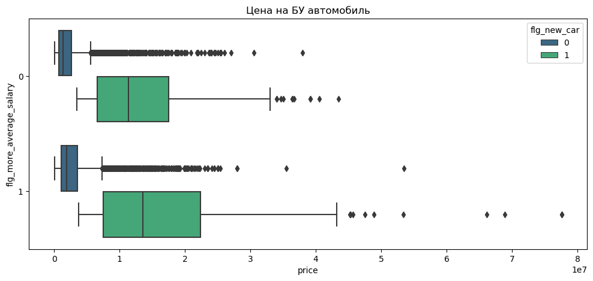

```python
plt.figure(figsize=(12, 5))

sns.boxplot(data=df,
            x='price',
            y='flg_more_average_salary',
            hue='flg_new_car',
            orient="h",
            palette='viridis')
plt.title('Цена на БУ автомобиль')
plt.show()
```

Видим, ориентируясь по медианам, что чуть более высокую цену порядка на 500 тыс рублей в регионах с ЗП выше среднего (около 30%), также если посмотреть на концы усов, увидим аналогичную ситуацию, причем начальная цена стартует почти из одной и той же точки.

## 2 Цена машины коррелирует со средней зарплатой в регионе

Посмотрим на корреляцию между данными признаками, заодно глянет и на другие

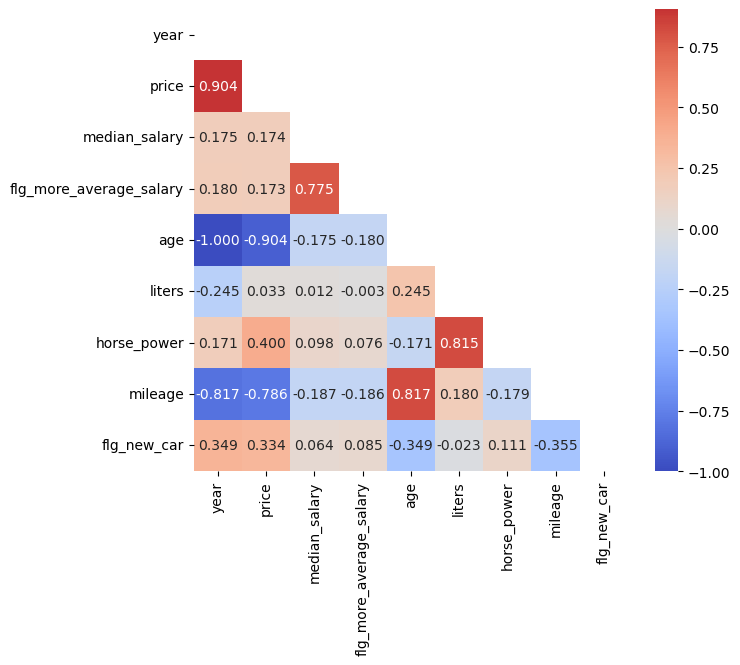

```python
matrix = np.triu(df.iloc[:, 1:].corr(method='spearman'))

plt.figure(figsize=(7, 6))

sns.heatmap(df.iloc[:, 1:].corr(method='spearman'),
            annot=True,
            fmt='.3f',
            center=0,
            cmap='coolwarm',
            mask=matrix)
plt.show()
```

Единственное, что можно сказать, это то, что цена коррелирует с годом (чем новее машина, тем дороже)

А также то, что чем больше пробег, тем меньше цена. Но данные выводы всем и так известны, поэтому отдельно их рассматривать нет смысла

## 3 Есть различия в цене в разрезе значений типа двигателя, коробки передач, трансмиссии, конструкции трансмиссии

```python
price_df = df[['type_engine', 'transmission', 'machine_drive',
               'price']].melt(id_vars=['price'])
```

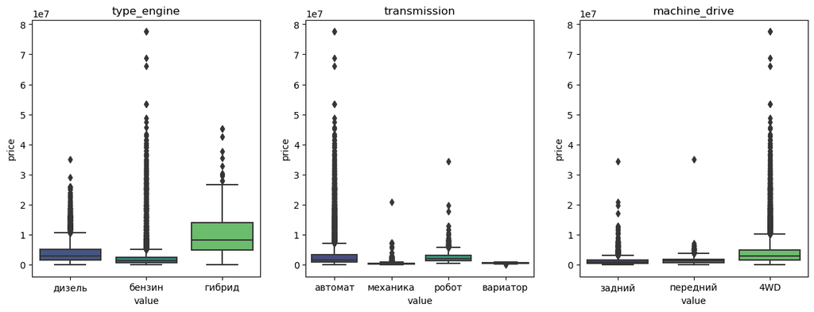

```python
fig, axes = plt.subplots(ncols=3, figsize=(15, 5))

for num, val in enumerate(price_df.variable.unique()):
    sns.boxplot(data=price_df[price_df.variable == val],
                y='price',
                x='value',
                palette=colors[0],
                ax=axes[num]).set_title(val)

plt.show()
```

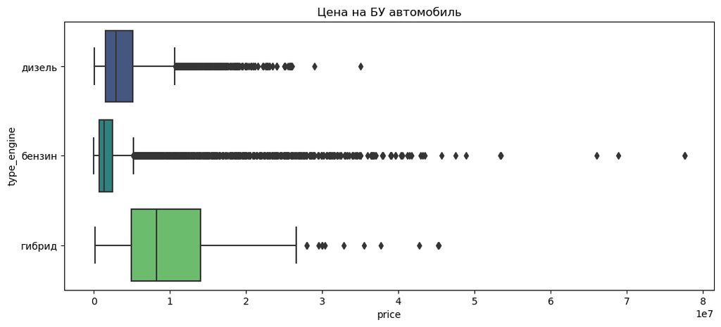

```python
plt.figure(figsize=(12, 5))

sns.boxplot(data=df,
            x='price',
            y='type_engine',
            orient="h",
            palette='viridis')
plt.title('Цена на БУ автомобиль')
plt.show()
```

Гибрид самый дорогой

автомат и робот также самые дорогие

полноприводные более дорогии

## 4 Цена на автомобили выше в регионах со средней ЗП выше средней по стране

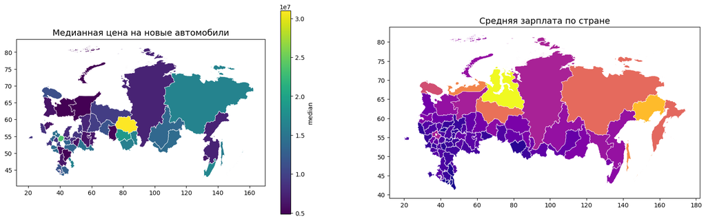

```python
fig, axes = plt.subplots(ncols=2, figsize=(20, 6))

plot_auto_geo(data=df[df.flg_new_car == 1],
              geo_data=russia_salary_geo,
              title='Медианная цена на новые автомобили',
              cmap=colors[0],
              agg_col='price',
              func='median',
              group_col='NAME_1',
              ax=axes[0])

mo_gdf_wm = russia_salary_geo.to_crs({'init': 'epsg:4326'})
mo_gdf_wm.plot(column='median_salary',
               linewidth=0.5,
               cmap=colors[1],
               legend_kwds={
                   'label': "median salary",
                   'orientation': "vertical"
               },
               edgecolor="white",
               ax=axes[1],
               aspect='auto')
axes[1].set_title('Средняя зарплата по стране', fontdict={'fontsize': 14})
plt.show()
```

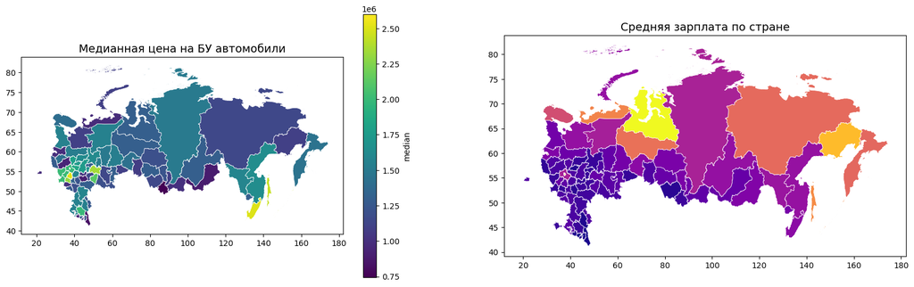

```python
fig, axes = plt.subplots(ncols=2, figsize=(20, 6))

plot_auto_geo(data=df[df.flg_new_car == 0],
              geo_data=russia_salary_geo,
              title='Медианная цена на БУ автомобили',
              cmap=colors[0],
              agg_col='price',
              func='median',
              group_col='NAME_1',
              ax=axes[0])

mo_gdf_wm = russia_salary_geo.to_crs({'init': 'epsg:4326'})
mo_gdf_wm.plot(column='median_salary',
               linewidth=0.5,
               cmap=colors[1],
               legend_kwds={
                   'label': "median salary",
                   'orientation': "vertical"
               },
               edgecolor="white",
               ax=axes[1],
               aspect='auto')
axes[1].set_title('Средняя зарплата по стране', fontdict={'fontsize': 14})
plt.show()
```

Нет никакой корреляции как для БУ, так и для новых автомобилей